# Spruce wood time series seasonal expression variation assessment

Nicolas Delhomme

2017-10-23

# 1 Rationale

The aim of this analysis is to check whether samples can be compared across seasons, *i.e.* if the amount of mRNA identified is constant throughout the year; to ensure that the normalisation does not introduce an artefactual mRNA abundance bias

# 2 Setup

The working dir

```r
setwd("/mnt/picea/projects/spruce/htuominen/27_SpruceTimeSeries")
```

Libraries

```r
suppressPackageStartupMessages(library(gplots))
suppressPackageStartupMessages(library(hyperSpec))
suppressPackageStartupMessages(library(IRanges))
suppressPackageStartupMessages(library(LSD))
suppressPackageStartupMessages(library(RColorBrewer))
suppressPackageStartupMessages(library(VennDiagram))
```

Helper files

```r
source("~/Git/UPSCb/src/R/featureSelection.R")
```

Graphics

```r
pal <- brewer.pal(8,"Dark2")
cols <- brewer.pal(10,"RdYlBu")
hpal <- colorRampPalette(colors = c("blue","white","red"))(100)
```

The data

```r
load(file="analysis/vst_blind-and-aware_results.rda")
```

Read the sample information

```r
samples <- read.csv("~/Git/UPSCb/projects/spruce-wood-time-series/doc/samplesmod.csv")
samples <- samples[order(samples$Tissue,samples$Sampling),]
```

Get the months

```r
months <- substr(samples$Date,1,3)
months[samples$Tissue=="Phloem"][duplicated(months[samples$Tissue=="Phloem"])] <- ""
months[samples$Tissue=="Xylem"][duplicated(months[samples$Tissue=="Xylem"])] <- ""
```

Identify the winter samples

```r
winterPos <- reduce(IRanges(start=grep("Oct|Nov|Dec|Jan|Feb",samples$Date),width=1))
tissuePos <- which(samples$Tissue=="Xylem")[1] - 0.5
```

Sort the data

```r
vst <- vst[,match(samples$Filename,colnames(vst))]
```

# 3 Analysis

## 3.1 select genes that are expressed in a biologically relevant way

```r
sel <- featureSelect(vst,conditions = factor(sprintf("%s%02d",samples$Tissue,samples$Sampling)),
                     exp=5,nrep=2)
```

## 3.2 Number of genes expressed over a cutoff

Vertical dashed lines represent the Oct-Feb months for the Phloem (green) and Xylem (orange) samples.

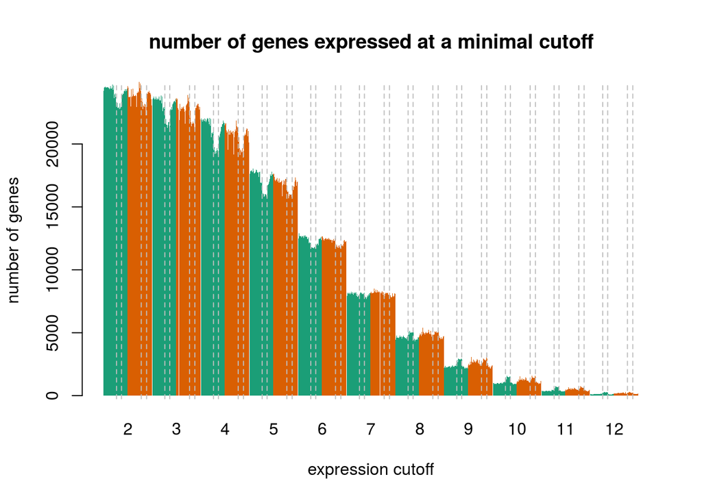

```r
barplot(sapply(2:12,function(ct){
  colSums(vst[sel,] >= ct)
}),beside=TRUE,col=pal[as.integer(samples$Tissue)],
xlab ="expression cutoff",
names.arg = 2:12,ylab="number of genes",
main="number of genes expressed at a minimal cutoff",
border=NA)
abline(v=as.vector(sapply(c(start(winterPos),end(winterPos)),
                          function(i){c(1,(nrow(samples) +1)* 1:10) + i})),
       lty=2,col="gray",lwd=1)
```

```r
pdf("analysis/season/supplementary-figure-2A.pdf",width=10,height=10)
barplot(sapply(2:12,function(ct){
  colSums(vst[sel,] >= ct)
}),beside=TRUE,col=pal[as.integer(samples$Tissue)],
xlab ="expression cutoff",
names.arg = 2:12,ylab="number of genes",
main="number of genes expressed at a minimal cutoff",
border=NA)
abline(v=as.vector(sapply(c(start(winterPos),end(winterPos)),
                          function(i){c(1,(nrow(samples) +1)* 1:10) + i})),
       lty=2,col="gray",lwd=1)
dev.off()
```

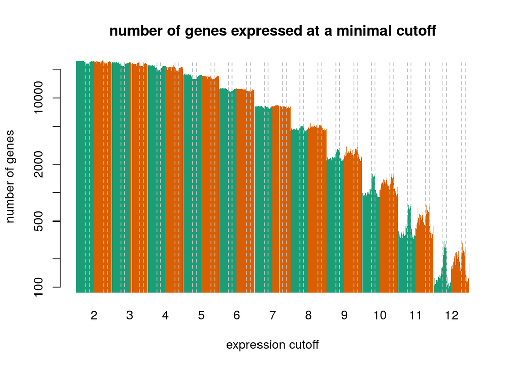

```r
barplot(sapply(2:12,function(ct){
  colSums(vst[sel,] >= ct)
}),beside=TRUE,col=pal[as.integer(samples$Tissue)],
xlab ="expression cutoff",names.arg = 2:12,
log="y",ylab="number of genes",
main="number of genes expressed at a minimal cutoff",
border=NA)
abline(v=as.vector(sapply(c(start(winterPos),end(winterPos)),
                          function(i){c(1,(nrow(samples) +1)* 1:10) + i})),
       lty=2,col="gray",lwd=1)
```

## 3.3 Number of genes accounting for a proportion of expression

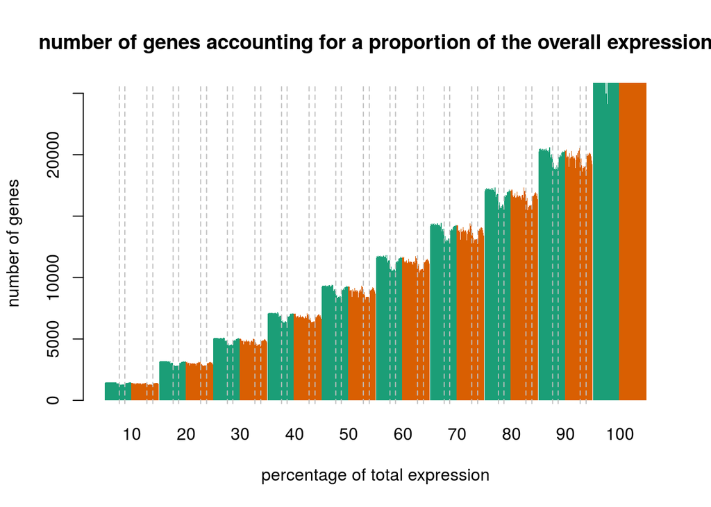

```r
barplot(sapply(seq(0.1,1,0.1),function(ct,mat){
  colSums(mat <= ct)
},t(t(apply(apply(vst[sel,],2,sort,decreasing=TRUE),2,cumsum))/colSums(vst[sel,]))),
beside=TRUE,col=pal[as.integer(samples$Tissue)],
xlab ="percentage of total expression",
names.arg = seq(10,100,10),ylab="number of genes",border=NA,
main="number of genes accounting for a proportion of the overall expression")
abline(v=as.vector(sapply(c(start(winterPos),end(winterPos)),
                          function(i){c(1,(nrow(samples) +1)* 1:8) + i})),
       lty=2,col="gray",lwd=1)
```

```r
pdf("analysis/season/supplementary-figure-2B.pdf",width=10,height=10)
barplot(sapply(seq(0.1,1,0.1),function(ct,mat){
  colSums(mat <= ct)
},t(t(apply(apply(vst[sel,],2,sort,decreasing=TRUE),2,cumsum))/colSums(vst[sel,]))),
beside=TRUE,col=pal[as.integer(samples$Tissue)],
xlab ="percentage of total expression",
names.arg = seq(10,100,10),ylab="number of genes",border=NA,
main="number of genes accounting for a proportion of the overall expression")
abline(v=as.vector(sapply(c(start(winterPos),end(winterPos)),
                          function(i){c(1,(nrow(samples) +1)* 1:8) + i})),
       lty=2,col="gray",lwd=1)
dev.off()
```

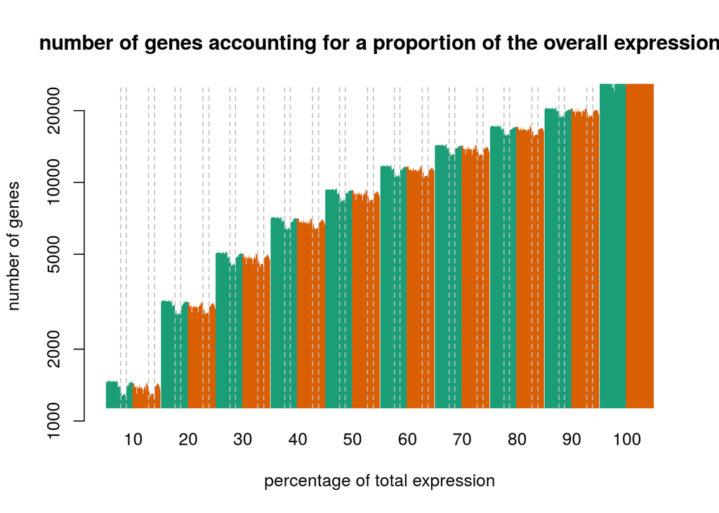

```r
barplot(sapply(seq(0.1,1,0.1),function(ct,mat){
  colSums(mat <= ct)
},t(t(apply(apply(vst[sel,],2,sort,decreasing=TRUE),2,cumsum))/colSums(vst[sel,]))),
beside=TRUE,col=pal[as.integer(samples$Tissue)],
xlab ="percentage of total expression",
names.arg = seq(10,100,10),ylab="number of genes",log="y",border=NA,
main="number of genes accounting for a proportion of the overall expression")
abline(v=as.vector(sapply(c(start(winterPos),end(winterPos)),
                          function(i){c(1,(nrow(samples) +1)* 1:8) + i})),
       lty=2,col="gray",lwd=1)
```

## 3.4 Expression Bins

### 3.4.1 Expression levels

The expression values are split into 10 bins (*i.e.* the range min expression - max expression, divided into 10 equivalently sized bins)

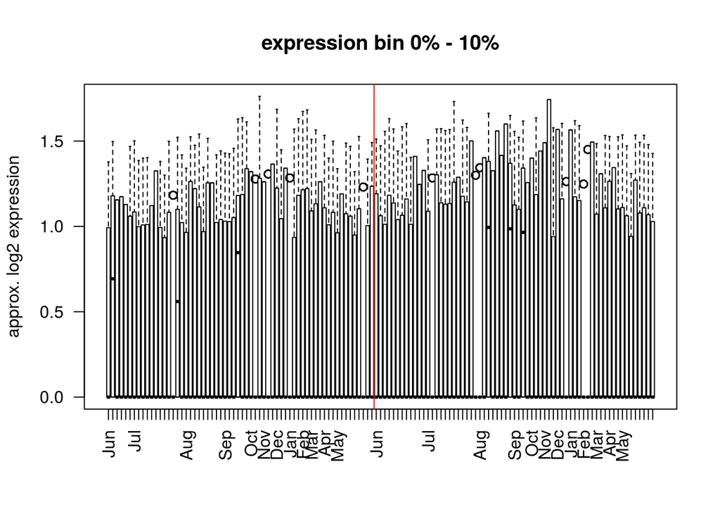

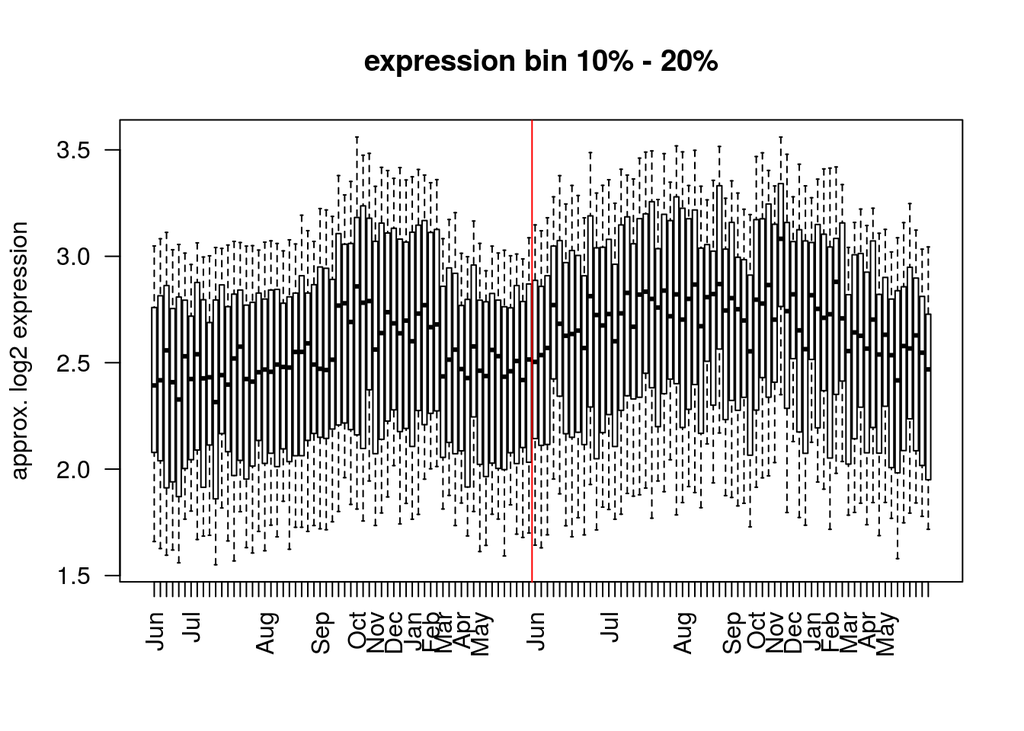

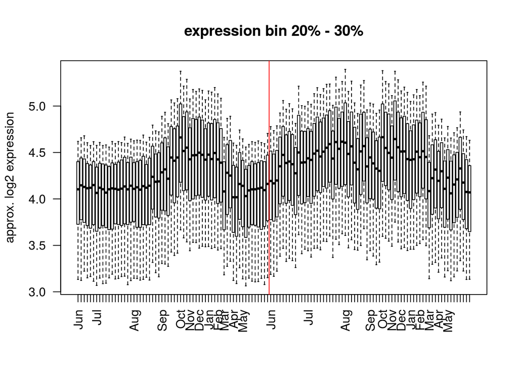

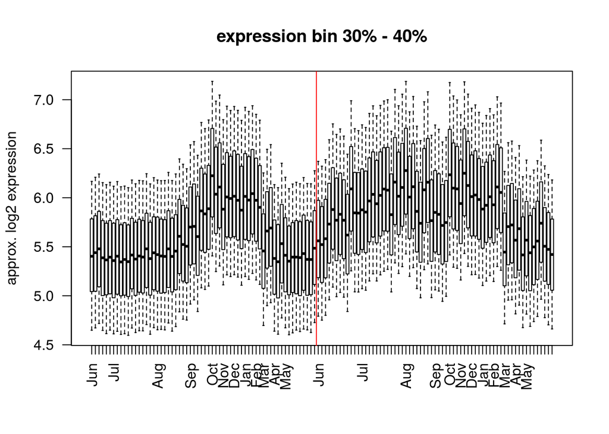

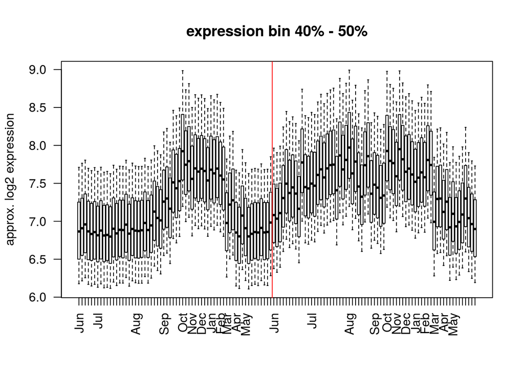

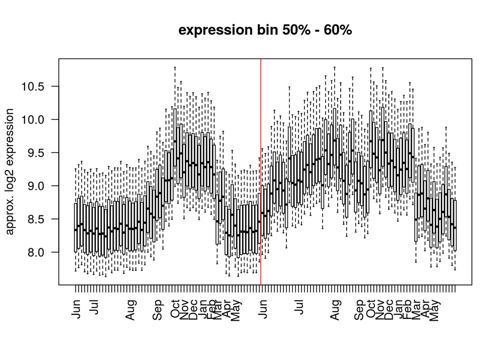

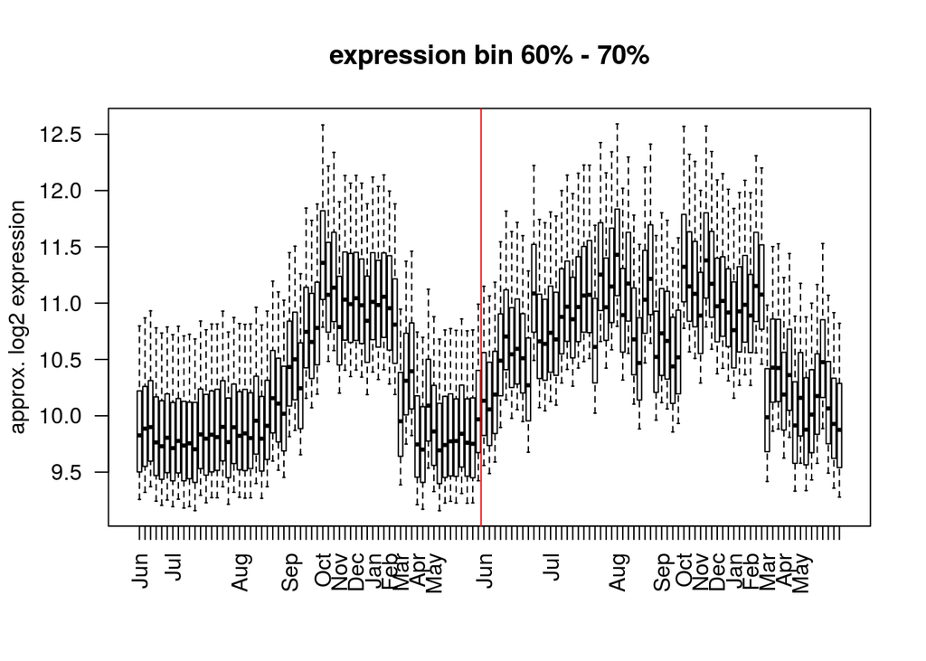

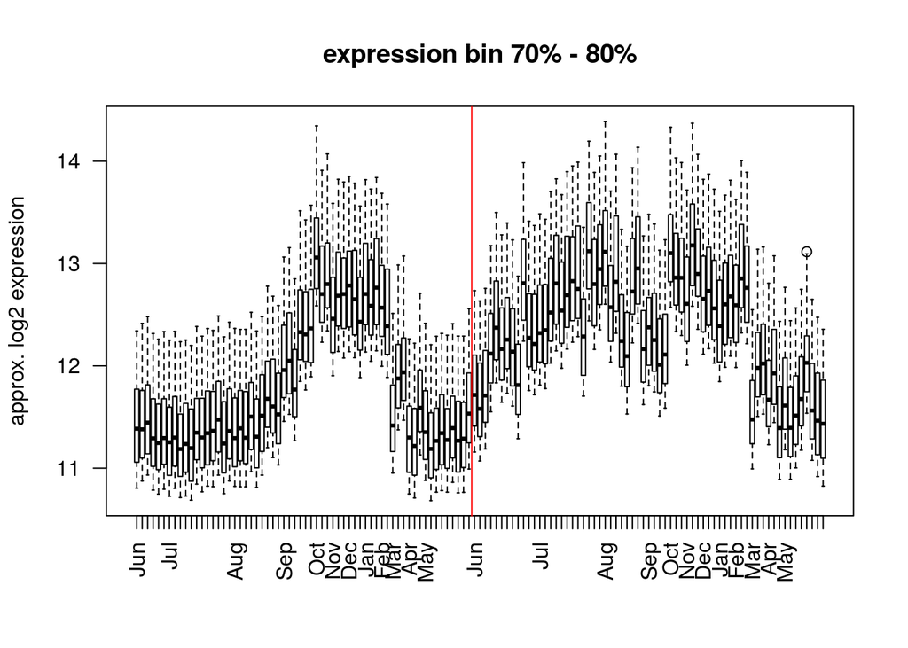

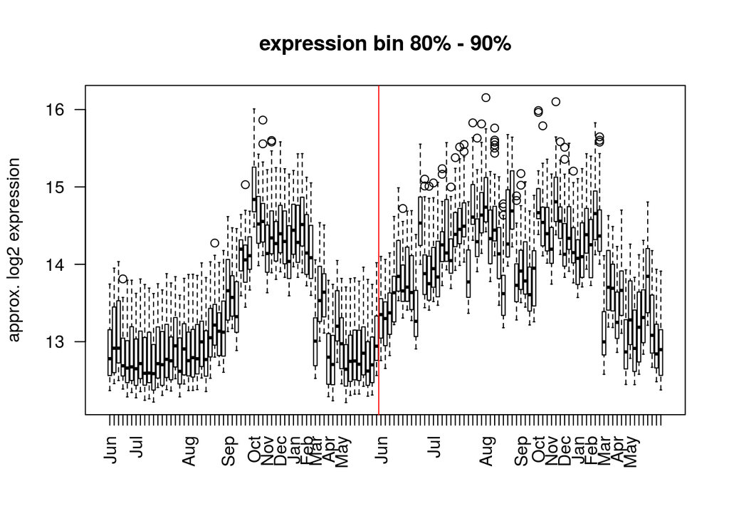

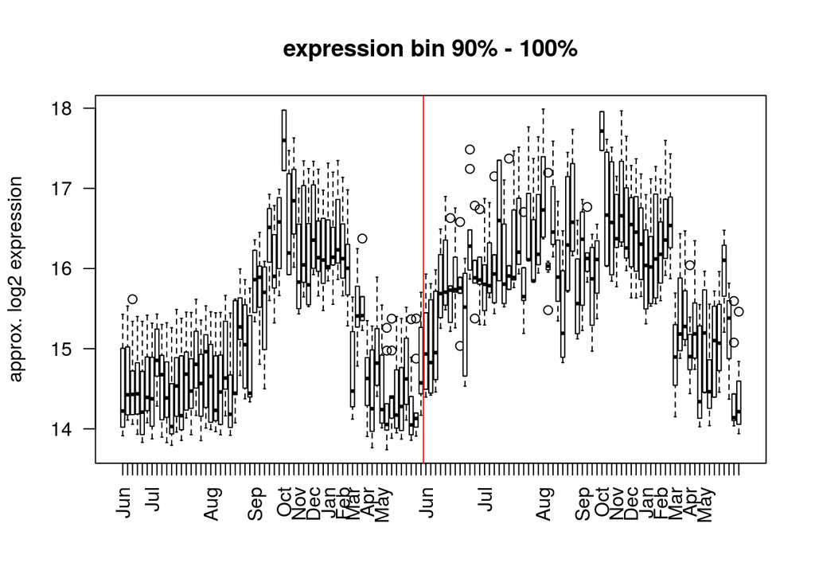

```r
bins <- apply(vst[sel,],2,function(co){split(co,cut(co,10))})
dev.null <- sapply(1:10,function(i){
  boxplot(lapply(bins,"[[",i),las=2,
          names=months,
  main=sprintf("expression bin %d%% - %d%%",(i-1)*10,i*10),
  xlab="",ylab="approx. log2 expression")
  abline(v=tissuePos,col=2)})
```

### 3.4.2 Number of genes per bins

```r
bSize <- sapply(bins,function(b){sapply(b,length)})
#barplot(bSize,beside = TRUE)
```

The colors got from red to yellow to blue - across all (0-10% to 90-100%) bins

It is interesting to see that there are more genes contributing to low expression bins and conversely less genes contributing to higher expression in the winter months Also here it is more apparent that the effect in the xylem is less pronounced than in the phloem. There is also an early season effect, which is probably related to wood development.

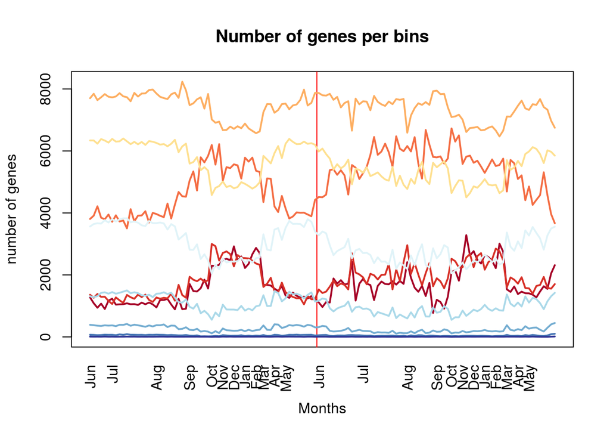

```r
plot(0,0,xlim=c(1,ncol(bSize)),ylim=range(bSize),type="n",xaxt="n",
     ylab="number of genes",xlab="Months",main="Number of genes per bins")
axis(1,tick = FALSE,labels=months,at=1:ncol(bSize),las=2)
abline(v=tissuePos,col=2)
dev.null <- sapply(1:nrow(bSize),function(i){lines(bSize[i,],col=cols[i],lwd=2)})
```

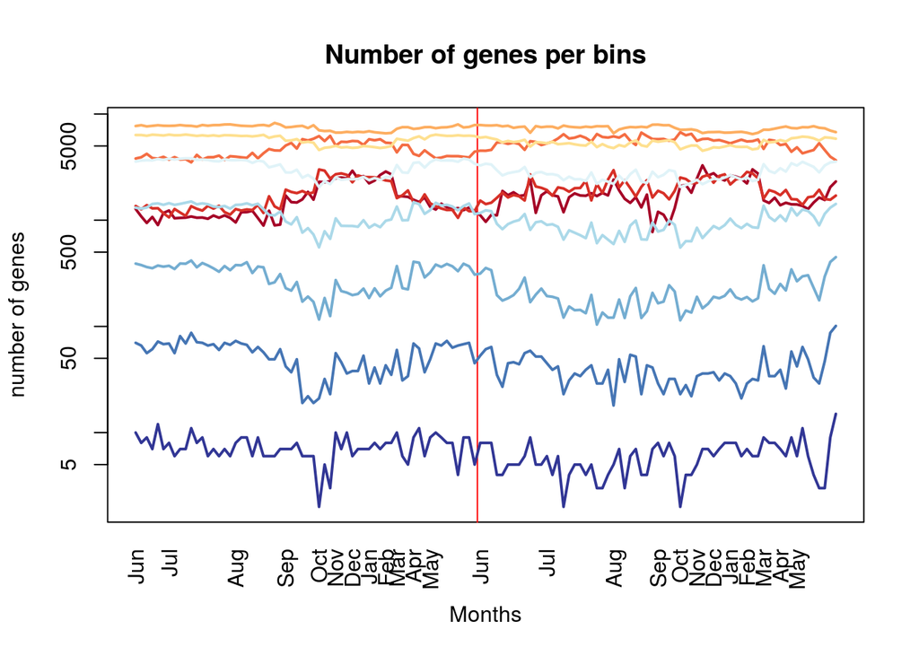

```r
plot(1,1,xlim=c(1,ncol(bSize)),ylim=range(bSize),type="n",xaxt="n",
     ylab="number of genes",xlab="Months",log="y",main="Number of genes per bins")
axis(1,tick = FALSE,labels=months,at=1:ncol(bSize),las=2)
abline(v=tissuePos,col=2)
dev.null <- sapply(1:nrow(bSize),function(i){lines(bSize[i,],col=cols[i],lwd=2)})
```